# DAT 402 Project 2- Sokolski

Before starting, I note that a large amount of outside sources served as an inspiration for the methodology behind this project. All final feature decisions, project narrative & structure, and presentation & interpretation are my own.

-Arizona State University DAT 402 Homework Assignments & past student projects served as inspiration for choice in machine learning methods and how I approached them. All staff and creators behind these sources have my thanks.

-Chat GPT served as a resource for formatting and troubleshooting specific code.  
https://chat.openai.com/

-"Python for Data Science & Machine Learning" by Jose Portilla, an instructional course on Udemy, also helped in approaching chosen machine learning methods, particularly in Principal Compenent Analysis. https://www.udemy.com/course/python-for-data-science-and-machine-learning-bootcamp/?utm_source=adwords&utm_medium=udemyads&utm_campaign=Python_Search_la.EN_cc.US_PP_Experiment&utm_content=deal4584&utm_term=_._ag_136282774539_._ad_595066904793_._kw__._de_c_._dm__._pl__._ti_dsa-1652644802545_._li_9016065_._pd__._&matchtype=&gad_source=1&gclid=Cj0KCQjw_qexBhCoARIsAFgBlevaWMdStjlLJEj5wdRmZynxoLA1kiZeD0toxewWk60FGsETKg-DjKcaApfoEALw_wcB&couponCode=ST6MT42324

```python
import pandas as pd
import seaborn as sns
import matplotlib.pyplot as plt
import numpy as np

import warnings
warnings.filterwarnings("ignore", message="Do not pass an `input_shape`/`input_dim` argument to a layer.*")

from sklearn.preprocessing import StandardScaler
from sklearn.decomposition import PCA
from sklearn.model_selection import train_test_split, cross_val_score, StratifiedKFold
from sklearn.linear_model import LogisticRegression
from sklearn.metrics import roc_curve, precision_recall_curve, auc, precision_recall_curve, average_precision_score, accuracy_score, classification_report, confusion_matrix
from sklearn.datasets import make_classification

from keras.models import Sequential
from keras.layers import Dense
```

# Dataset

The goal of this project is to predict whether a customer makes a sale based on their activity and its context on a shopping website. The main methods used to accomplish this will be Principal Component Analysis, Logistic Regression, & an Artificial Neural Network.

The data set comes from the "Online Shoppers Purchasing Intention Dataset" found on the UC Irvine Machine Learning Repository.

The link is here: https://archive.ics.uci.edu/dataset/468/online+shoppers+purchasing+intention+dat

And the original publication is here: https://www.semanticscholar.org/paper/Real-time-prediction-of-online-shoppers%E2%80%99-purchasing-Sakar-Polat/747e098f85ca2d20afd6313b11242c0c427e6fb3 (credit to authors C.O. Sakar, S. Polat, M Katricioglu, & Y. Kastro)aset

```python
file_path = r'C:\Users\bssok\OneDrive\Desktop\Project 2 Dataset\shop.csv'

df = pd.read_csv(file_path)

print(df.head())

columns, rows  = df.shape

print("Categories:", columns)
print("Observations:", rows)
```

```
   Administrative  Administrative_Duration  Informational  \
0               0                      0.0              0
1               0                      0.0              0
2               0                      0.0              0
3               0                      0.0              0
4               0                      0.0              0

   Informational_Duration  ProductRelated  ProductRelated_Duration  \
0                     0.0               1                 0.000000
1                     0.0               2                64.000000
2                     0.0               1                 0.000000
3                     0.0               2                 2.666667
4                     0.0              10               627.500000

   BounceRates  ExitRates  PageValues  SpecialDay Month  OperatingSystems  \
0         0.20       0.20         0.0         0.0   Feb                 1
1         0.00       0.10         0.0         0.0   Feb                 2
2         0.20       0.20         0.0         0.0   Feb                 4
3         0.05       0.14         0.0         0.0   Feb                 3
4         0.02       0.05         0.0         0.0   Feb                 3

   Browser  Region  TrafficType        VisitorType  Weekend  Revenue
0        1       1            1  Returning_Visitor    False    False
1        2       1            2  Returning_Visitor    False    False
2        1       9            3  Returning_Visitor    False    False
3        2       2            4  Returning_Visitor    False    False
4        3       1            4  Returning_Visitor     True    False
Categories: 12330
Observations: 18
```

We have a large dataset gathered from an Excel file with over 12000 entries, and 18 features.

From the source, 'Revenue', is the target variable and tells whether there is a sale or not.

- The first 6 categories relate to types of pages visited and time spent on each page.
- The next three, 'BounceRates', 'ExitRates', 'PageValues', measure certain ways customer interact with pages.
- The rest are pretty much self-explanatory, and largely deal with date & the customer's locality.

# Preprocessing

Missing Values: None

```python
missing_values = df.isnull().sum()
print(missing_values)
```

```
Administrative             0
Administrative_Duration    0
Informational              0
Informational_Duration     0
ProductRelated             0
ProductRelated_Duration    0
BounceRates                0
ExitRates                  0
PageValues                 0
SpecialDay                 0
Month                      0
OperatingSystems           0
Browser                    0
Region                     0
TrafficType                0
VisitorType                0
Weekend                    0
Revenue                    0
dtype: int64
```

Encoding: Assigns numerical values to categories

```python
categorical_features = ['Month', 'VisitorType']
encoded_features = pd.get_dummies(df[categorical_features])

df = pd.concat([df, encoded_features], axis=1)

df.drop(categorical_features, axis=1, inplace=True)
```

Scaling: standardize numerical features

```python
numerical_features = ['Administrative', 'Administrative_Duration', 'Informational',
                      'Informational_Duration', 'ProductRelated', 'ProductRelated_Duration',
                      'BounceRates', 'ExitRates', 'PageValues', 'SpecialDay',
                      'OperatingSystems', 'Browser', 'Region', 'TrafficType']

scaler = StandardScaler()

df[numerical_features] = scaler.fit_transform(df[numerical_features])
```

# Exploration & Visualization

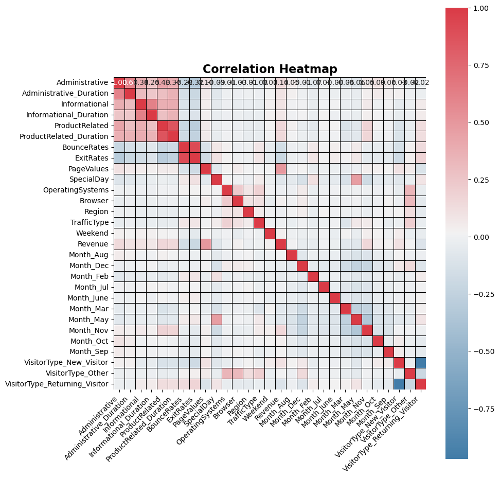

```python
correlation_matrix = df.corr()

colors = sns.diverging_palette(240, 10, as_cmap=True)

plt.figure(figsize=(10, 10))
sns.heatmap(correlation_matrix, annot=True, cmap=colors, fmt=".2f", linewidths=0.5, linecolor='black', square=True)
plt.title('Correlation Heatmap', fontsize=16, fontweight='bold')
plt.xticks(rotation=45, ha='right', fontsize=10)
plt.yticks(fontsize=10)
plt.tight_layout()
plt.show()
```

Looking at out target variable, Revenue, the strongest connection appears to be with BounceRates, ExitRates, and PageValues (which again measure how a customer interacts with the page). Their grouping together helps inform us of how they could loaded together during Principal Component Analysis). Also, strong correlation is seen with the first six columns, there in the top left corner, which again gives possible insight into the PCA step.

# Principal Component Analysis- Exploration & Dimensionality Reduction

```python
pca = PCA()
pca.fit(df[numerical_features])

explained_variance_ratio = pca.explained_variance_ratio_
print("Explained Variance Ratio:", explained_variance_ratio)

cumulative_variance_ratio = np.cumsum(explained_variance_ratio)
print("Cumulative Explained Variance Ratio:", cumulative_variance_ratio)

num_components = np.argmax(cumulative_variance_ratio >= 0.95) + 1
print("Number of components to keep:", num_components)

pca = PCA(n_components=num_components)
pca_features = pca.fit_transform(df[numerical_features])

pca_columns = [f"PC{i}" for i in range(1, num_components + 1)]
df_pca = pd.DataFrame(data=pca_features, columns=pca_columns)
df = pd.concat([df, df_pca], axis=1)

df.drop(numerical_features, axis=1, inplace=True)
```

```
Explained Variance Ratio: [0.24345442 0.12039984 0.10000861 0.0770045  0.07214249 0.06914043
 0.06785531 0.06531362 0.06133242 0.05382567 0.03009925 0.02511474
 0.00877426 0.00553445]
Cumulative Explained Variance Ratio: [0.24345442 0.36385425 0.46386287 0.54086736 0.61300985 0.68215029
 0.7500056  0.81531921 0.87665164 0.9304773  0.96057655 0.98569129
 0.99446555 1.        ]
Number of components to keep: 11
```

This code is showing us that 11 principal components are going to be used, and the rest should be dropped. The Explained Variance Ratio shows how significant each component is- the first once accounts for about 24% of variation in the data, so its pretty significant. And looking at the cumulative, one sees that by the time we reach 11, we're able to account for about 96% of variance.

This accomplishes dimensionality reduction, which helps us interpret and visualize our results more clearly. We chose a 95% cutoff to avoid a large amount of information loss, while still reaping some benefits of the analysis.

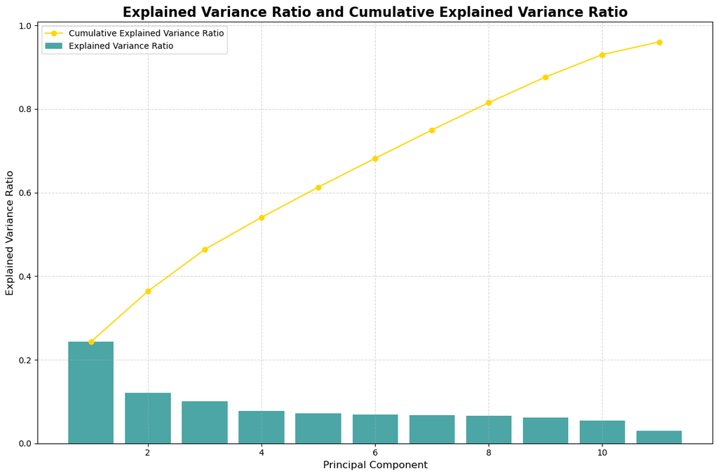

```python
explained_variance_ratio = pca.explained_variance_ratio_

cumulative_variance_ratio = np.cumsum(explained_variance_ratio)

plt.figure(figsize=(12, 8))
plt.bar(range(1, len(explained_variance_ratio) + 1), explained_variance_ratio, alpha=0.7, align='center', label='Explained Variance Ratio', color='teal')
plt.plot(range(1, len(cumulative_variance_ratio) + 1), cumulative_variance_ratio, marker='o', linestyle='-', color='gold', label='Cumulative Explained Variance Ratio')
plt.xlabel('Principal Component', fontsize=12)
plt.ylabel('Explained Variance Ratio', fontsize=12)
plt.title('Explained Variance Ratio and Cumulative Explained Variance Ratio', fontsize=16, fontweight='bold')
plt.legend(fontsize=10)
plt.grid(True, linestyle='--', alpha=0.5)
plt.xticks(fontsize=10)
plt.yticks(fontsize=10)
plt.tight_layout()
plt.show()
```

This visualization helps make the above easier to understand, where there's diminishing returns as each component is added- shown by the green bars, and where there's a good amount of exaplined variance- shown by the yellow line.

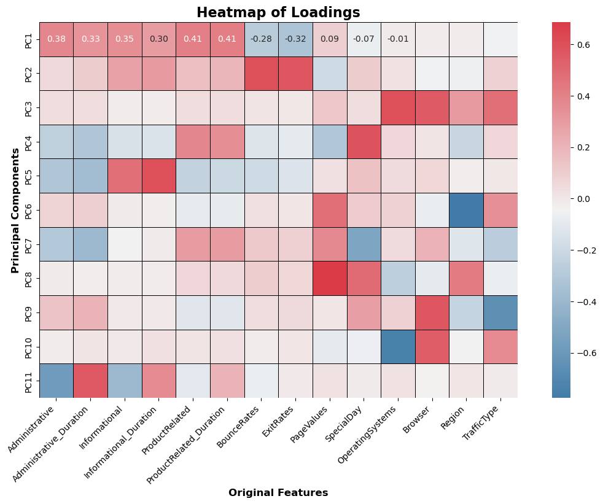

```python
loadings = pca.components_
loadings_df = pd.DataFrame(loadings, columns=numerical_features, index=[f'PC{i+1}' for i in range(11)])

colors = sns.diverging_palette(240, 10, as_cmap=True)

plt.figure(figsize=(12, 8))
sns.heatmap(loadings_df,
            annot=True,
            cmap=colors,
            fmt=".2f",
            linewidths=0.5,
            linecolor='black',
            square=True)
plt.title('Heatmap of Loadings', fontsize=16, fontweight='bold')
plt.xlabel('Original Features', fontsize=12, fontweight='bold')
plt.ylabel('Principal Components', fontsize=12, fontweight='bold')
plt.xticks(rotation=45, ha='right', fontsize=10)
plt.yticks(fontsize=10)
plt.tight_layout()
plt.show()
```

This visualization shows how our original variables factored into our new principal components. This provides exploration as it gives even more insight into the effect of our variables than our previous heatmap did. The first component is made up of those first six features that we discussed earlier, and which were confirmed by the authors of the dataset to measure similar activity. Also, one sees that in each component, BounceRates, ExitRates, and PageValues, often operate together (although PageValues is often in the inverse direction), which again was similarly grouped. Overall it's encouraging to see that the groupings by the authors and our exploratory analysis agree with the PCA.

# Logistic Regression

Train / Test Split

```python
X_train, X_test, y_train, y_test = train_test_split(pca_features, df['Revenue'], test_size=0.2, random_state=42)
```

Model

```python
log_reg = LogisticRegression()
log_reg.fit(X_train, y_train)


train_predictions = log_reg.predict(X_train)
test_predictions = log_reg.predict(X_test)

train_accuracy = accuracy_score(y_train, train_predictions)
test_accuracy = accuracy_score(y_test, test_predictions)

print("Training Accuracy:", train_accuracy)
print("Testing Accuracy:", test_accuracy)
```

```
Training Accuracy: 0.8858475263584753
Testing Accuracy: 0.8698296836982968
```

These figures show that accuracy for training and testing is pretty high, suggesting our model is good as measuring data its seen before and data it hasn't.

```python
print("\nClassification Report:")
print(classification_report(y_test, test_predictions))
```

```
Classification Report:
              precision    recall  f1-score   support

       False       0.88      0.98      0.93      2055
        True       0.74      0.34      0.47       411

    accuracy                           0.87      2466
   macro avg       0.81      0.66      0.70      2466
weighted avg       0.86      0.87      0.85      2466
```

Looking at the classification report here, one does see some standout figures. The True (0.34) Recall figure suggests are model needs more improvement in getting true positives right. Similarly, with the True(0.47) F1-score, there may be a problem with how are model sorts petween True precision and recall.

```python
X, y = make_classification(n_samples=1000, n_features=10, n_classes=2, random_state=42)

log_reg = LogisticRegression()

cv = StratifiedKFold(n_splits=5, shuffle=True, random_state=42)

cv_scores = cross_val_score(log_reg, X, y, cv=cv, scoring='accuracy')

print("Cross-Validation Scores:", cv_scores)
print("Mean CV Accuracy:", cv_scores.mean())
print("Standard Deviation of CV Accuracy:", cv_scores.std())
```

```
Cross-Validation Scores: [0.83  0.84  0.875 0.89  0.845]
Mean CV Accuracy: 0.8560000000000001
Standard Deviation of CV Accuracy: 0.022671568097509285
```

Receiver Operating Characteristic Curve

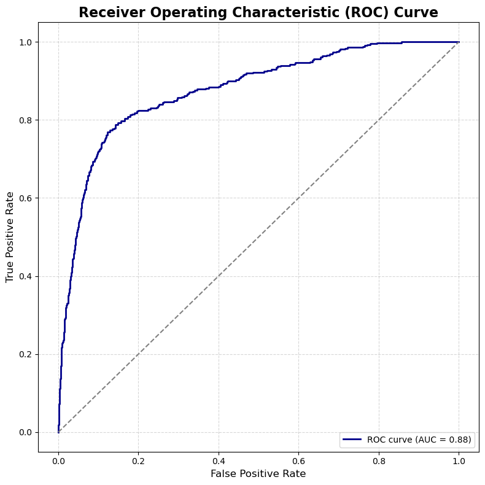

```python
log_reg.fit(X_train, y_train)

y_pred_prob = log_reg.predict_proba(X_test)[:, 1]

fpr, tpr, _ = roc_curve(y_test, y_pred_prob)
roc_auc = auc(fpr, tpr)

precision, recall, _ = precision_recall_curve(y_test, y_pred_prob)
pr_auc = auc(recall, precision)

plt.figure(figsize=(8, 8))
plt.plot(fpr, tpr, color='darkblue', lw=2, label='ROC curve (AUC = %0.2f)' % roc_auc)
plt.plot([0, 1], [0, 1], color='grey', linestyle='--')
plt.xlim([-0.05, 1.05])
plt.ylim([-0.05, 1.05])
plt.xlabel('False Positive Rate', fontsize=12)
plt.ylabel('True Positive Rate', fontsize=12)
plt.title('Receiver Operating Characteristic (ROC) Curve', fontsize=16, fontweight='bold')
plt.legend(loc='lower right', fontsize=10)
plt.grid(True, linestyle='--', alpha=0.5)
plt.xticks(fontsize=10)
plt.yticks(fontsize=10)
plt.tight_layout()
plt.show()
```

This ROC curve visualizes a lot of what was discussed with our figures. Our model performs fairly well, where one sees the blue line hug the top left corner, and suggests that while there is room for improvement, it is good at identifying true positives while reducing the amount of false positives.

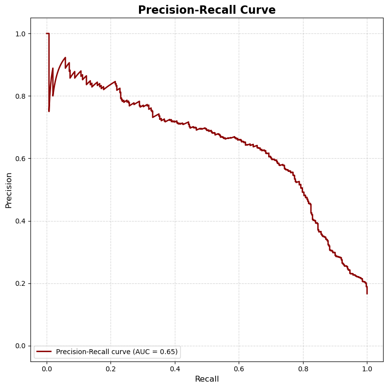

```python
plt.figure(figsize=(8, 8))
plt.plot(recall, precision, color='darkred', lw=2, label='Precision-Recall curve (AUC = %0.2f)' % pr_auc)
plt.xlim([-0.05, 1.05])
plt.ylim([-0.05, 1.05])
plt.xlabel('Recall', fontsize=12)
plt.ylabel('Precision', fontsize=12)
plt.title('Precision-Recall Curve', fontsize=16, fontweight='bold')
plt.legend(loc='lower left', fontsize=10)
plt.grid(True, linestyle='--', alpha=0.5)
plt.xticks(fontsize=10)
plt.yticks(fontsize=10)
plt.tight_layout()
plt.show()
```

This precision recall curve shows, I would say, fairly good results. It's challenging to achieve both good precision and recall, so some tradeoff is natural. There are a fair amount of false positives that can be seen, so there is room for improvement,, but I think we are at a good enough threshold to effectively use our model.